## Disease Page View CNV Plots

The Open Targets framework allows the user to view data from three perspectives: disease, gene, and evidence. The disease view shows all data relating to the given disease, including all genes. The gene view shows all data relating to the given gene, so showing information for that gene in all diseases. The evidence page view is the most specific showing data only for a single gene in a single disease.

### Data

#### hg38 Cytobands

Cytobands are used to define the chromosome ideograms for a reference genome. Cytoband data downloaded directly from UCSC at http://hgdownload.cse.ucsc.edu/goldenpath/hg38/database/cytoBand.txt.gz. This is for the backbone of the circos plot.

```r
vroom::vroom('http://hgdownload.cse.ucsc.edu/goldenpath/hg38/database/cytoBand.txt.gz',
             col_names = c('chr', 'start', 'end', 'band', 'stain')) -> hg38_cytobands
```

#### Pediatric Molecular Target List

Read in and get the locations of the pmtl genes.

```r
# read in table
vroom::vroom('../../../OpenPedCan-analysis/data/ensg-hugo-pmtl-mapping.tsv') -> pmtl_genes
# get the coordinates for the pmtl genes; run one time, was not working with
# Rmd knit when code was archived in this repository
# biomaRt::getBM(attributes = c('ensembl_gene_id', 'chromosome_name',
#                               'start_position', 'end_position'),
#                mart = biomaRt::useEnsembl(biomart = "genes",
#                                           dataset = "hsapiens_gene_ensembl"),
#                filters = 'ensembl_gene_id',
#                values = unique(pmtl_genes$ensg_id)) %>%
#   filter(chromosome_name %in% c(1:22, 'X', 'Y')) %>%
#   rename(chr = chromosome_name, start = start_position, end = end_position) -> gene_locs
# readr::write_tsv(inputs/gene_locs, 'gene_locs.tsv')
vroom('inputs/gene_locs.tsv') -> gene_locs
# combine pmtl genes with their locations
pmtl_genes %>%
  left_join(gene_locs, by = c('ensg_id' = 'ensembl_gene_id')) %>%
  arrange(gene_symbol) %>%
  group_by(gene_symbol) %>%
  filter(row_number() == 1) %>%
  ungroup() -> pmtl_genes_locs
```

### Copy Number Variants (CNV)

Read in metadata tables from `OpenPedCan-analysis`

```r
### histologies
# histology file has the metadata for each biospecimen like patient id, tumor type,
# sequenceing type, specimen type, cancer type, etc.
vroom::vroom('../../../OpenPedCan-analysis/data/histologies.tsv') -> histologies
### biospecimen list
# using the same one as the SNV frequencies module
# https://github.com/PediatricOpenTargets/OpenPedCan-analysis/tree/dev/analyses/snv-frequencies
# as Jo Lynne requested. Some samples are duplicated and this is a list of unique
# samples that all analyses use
vroom::vroom('../../../OpenPedCan-analysis/data/independent-specimens.wgswxspanel.primary.prefer.wxs.tsv') -> independent_specs
```

Actual table with CNVs, filtered for our independent specimens, for primary tumors, and to remove an outlier sample that was excluded for the purpose of development only.

```r
### cnvs
vroom::vroom('../../../OpenPedCan-analysis/data/consensus_wgs_plus_cnvkit_wxs.tsv.gz') %>%
  # filter for masterlist of biospecimen ids, for primary tumor only
  inner_join(filter(histologies, cancer_group == 'Neuroblastoma'),
             by = c('biospecimen_id' = 'Kids_First_Biospecimen_ID')) %>%
  filter(sample_type == 'Tumor', tumor_descriptor == 'Primary Tumor',
         !is.na(cancer_group), biospecimen_id != 'TARGET-10-PARDSP-09A-01D',
         biospecimen_id %in% independent_specs$Kids_First_Biospecimen_ID) %>%
  left_join(pmtl_genes_locs, by = c('ensembl' = 'ensg_id', 'gene_symbol')) %>%
  filter(copy_number != ploidy) -> cnv
```

### RNA-seq Data

```r
### rnaseq independent specs; same as for CNVs this makes sure we have one
# unique sample for each patient
vroom::vroom('../../../OpenPedCan-analysis/data/independent-specimens.rnaseqpanel.primary.tsv') -> rnaseq_independent_specs
```

#### Fusions

Fusion data is called from RNA-seq only

```r
# read in the fusion data, combine with metadata and filter for independent
# specimens and primary tumors
vroom::vroom('../../../OpenPedCan-analysis/data/fusion-putative-oncogenic.tsv') %>%
  inner_join(filter(histologies, cancer_group == 'Neuroblastoma'),
             by = c('Sample' = 'Kids_First_Biospecimen_ID')) %>%
  filter(sample_type == 'Tumor', tumor_descriptor == 'Primary Tumor',
         !is.na(cancer_group), Sample != 'TARGET-10-PARDSP-09A-01D',
         Sample %in% rnaseq_independent_specs$Kids_First_Biospecimen_ID) -> fusions
# reformat the fusions into GRanges format so they can be plotted in the circos
# plot
fusions %>%
  select(Sample, Gene1A:Gene2B) %>%
  tidyr::pivot_longer(Gene1A:Gene2B, names_to = 'fusion_position', values_to = 'gene') %>%
  na.omit() %>%
  filter(gene %in% cnv$gene_symbol) -> gene_w_cnv

fusions %>%
  filter(Gene1A %in% gene_w_cnv$gene | Gene1B %in% gene_w_cnv$gene) %>%
  select(Sample, LeftBreakpoint, RightBreakpoint, FusionName, Fusion_Type,
         Gene1A, Gene1B) %>%
  tidyr::pivot_longer(Gene1A:Gene1B,
                      names_to = 'fusion_position', values_to = 'gene') %>%
  left_join(pmtl_genes_locs, by = c('gene' = 'gene_symbol')) %>%
  select(-version) %>%
  tidyr::unite(temp, c('gene', 'ensg_id', 'pmtl', 'chr', 'start', 'end'), sep = ':') %>%
  distinct() %>%
  tidyr::pivot_wider(names_from = fusion_position, values_from = temp) %>%
  tidyr::separate(Gene1A, into = c('Gene1A', 'ensg1A', 'pmtl1A', 'chr1A', 'start1A', 'end1A'),
                  sep = ':', convert = T) %>%
  tidyr::separate(Gene1B, into = c('Gene1B', 'ensg1B', 'pmtl1B', 'chr1B', 'start1B', 'end1B'),
                  sep = ':', convert = T) %>%
  filter(!is.na(chr1A), !is.na(chr1B),
         pmtl1A == 'Relevant Molecular Target' |
           pmtl1B == 'Relevant Molecular Target') %>%
  count(FusionName, Gene1A, ensg1A, pmtl1A, chr1A, start1A, end1A,
        Gene1B, ensg1B, pmtl1B, chr1B, start1B, end1B, name = 'sample_count') %>%
  group_by(FusionName, Gene1A, pmtl1A, chr1A, start1A, end1A,
           pmtl1B, sample_count) %>%
  tidyr::nest() %>%
  ungroup() %>%
  mutate(partner = purrr::map(data,
                              ~ plyranges::as_granges(., seqnames = chr1B,
                                                      start = start1B, end = end1B))) %>%
  select(-data) %>%
  mutate(chr1A = factor(chr1A, levels = c(1:22, 'X', 'Y'))) %>%
  plyranges::as_granges(seqnames = chr1A, start = start1A, end = end1A) %>%
  mutate(partner = plyranges::as_granges(partner)) -> fusion_genes_granges
```

#### Gene Expression

Read in the gene expression data and like all the other tables, filter for independent specimens and primary tumors.

```r
readr::read_rds('../../../OpenPedCan-analysis/data/gene-expression-rsem-tpm-collapsed.rds') %>%
  tibble::rownames_to_column('gene') %>% #select(gene) %>% sample_n(100) -> random_genes
  dplyr::select(!contains('GTEX')) %>%
  tidyr::pivot_longer(2:ncol(.), names_to = 'biospecimen_id', values_to = 'tpm') %>%
  dplyr::inner_join(rnaseq_independent_specs,
            by = c('biospecimen_id' = 'Kids_First_Biospecimen_ID')) %>%
  dplyr::filter(Kids_First_Participant_ID %in% cnv$Kids_First_Participant_ID,
         tumor_descriptor == 'Primary Tumor',
         !is.na(cancer_group), cancer_group == 'Neuroblastoma') -> expression
```

### Disease Page Plot

#### Combine CNV and Expression Data

One layer has the correlation between CNVs and expression, so need to calculate and then convert into GRanges format for use in the circos plot.

```r
cnv %>%
  select(Kids_First_Participant_ID, ensembl, gene_symbol, copy_number) %>%
  left_join(select(expression, Kids_First_Participant_ID, gene, tpm),
            by = c('Kids_First_Participant_ID', 'gene_symbol' = 'gene')) %>%
  na.omit() %>%
  group_by(ensembl, gene_symbol) %>%
  summarize(cn_exp_cor = cor(copy_number, tpm)) %>%
  ungroup() -> cn_exp_cor
biomaRt::getBM(attributes = c('ensembl_gene_id', 'chromosome_name',
                              'start_position', 'end_position'),
               filters = 'ensembl_gene_id',
               values = cn_exp_cor$ensembl,
               mart = biomaRt::useEnsembl(biomart = "genes",
                                          dataset = "hsapiens_gene_ensembl")) %>%
  right_join(cn_exp_cor, by = c('ensembl_gene_id' = 'ensembl')) %>%
  na.omit() %>%
  plyranges::as_granges(seqnames = chromosome_name, start = start_position,
                        end = end_position) -> cn_exp_granges
```

#### Convert To GRanges

Convert any tables that are not already in GRanges format to that format.

```r
cnv %>%
  distinct(chr, start, end, ensembl, gene_symbol, copy_number, status) %>%
  filter(chr %in% c(1:22, 'X', 'Y')) %>%
  mutate(status = factor(status, levels = c('amplification', 'gain', 'neutral',
                                            'loss', 'deep deletion')),
         chr = factor(chr, levels = c(1:22, 'X', 'Y'))) %>%
  na.omit() %>%
  plyranges::as_granges(seqnames = chr) -> cnv_cn_granges

pmtl_genes_locs %>%
  filter(pmtl == 'Relevant Molecular Target') %>%
  filter(!is.na(start), !is.na(end)) %>%
  plyranges::as_granges(seqnames = chr) -> pmtl_granges

hg38_cytobands %>%
  filter(chr %in% c(paste0('chr', 1:22), 'chrX', 'chrY')) %>%
  mutate(chr = stringr::str_remove(chr, 'chr'),
         chr = factor(chr, levels = c(1:22, 'X', 'Y'))) %>%
  plyranges::as_granges(seqnames = chr) -> hg38_cytobands_granges

hg38_cytobands %>%
  group_by(chr) %>%
  summarize(start = min(start), end = max(end)) %>%
  ungroup() %>%
  filter(chr %in% c(paste0('chr', 1:22), 'chrX', 'chrY')) %>%
  mutate(chr = stringr::str_remove(chr, 'chr'),
         chr = factor(chr, levels = c(1:22, 'X', 'Y')),
         label = chr) %>%
  plyranges::as_granges(seqnames = chr) -> hg38_chr_labels
```

#### Plot

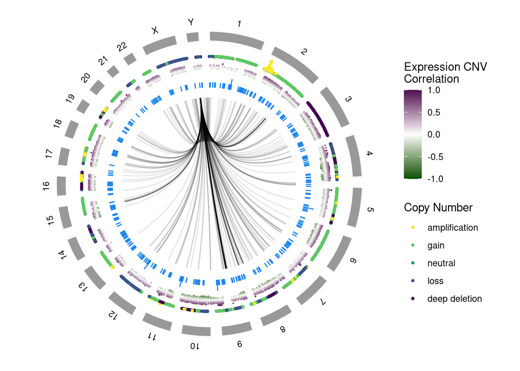

```r
ggbio::ggbio() +
  circle(fusion_genes_granges, geom = 'link', linked.to = 'partner',
         aes(alpha = sample_count)) +
  scale_alpha_continuous(guide = 'none') +
  circle(pmtl_granges, geom = 'rect', color = 'dodgerblue2') +
  ggbio::circle(cn_exp_granges, geom = 'point', size = 0.001,
                aes(y = cn_exp_cor, color = cn_exp_cor)) +
  scale_color_gradient2(low = '#005000', mid = "white", high = '#500d50',
                         midpoint = 0, limits = c(-1, 1)) +
  ggbio::circle(cnv_cn_granges, geom = 'point', shape = 21, stroke = 0.0001,
                aes(x = ranges, y = copy_number, fill = status)) +
  viridis::scale_fill_viridis(discrete = T, direction = -1, drop = F) +
  ggbio::circle(hg38_cytobands_granges, geom = 'ideogram', #trackWidth = 2,
                fill = 'gray60', color = 'white') +
  ggbio::circle(hg38_chr_labels, geom = 'text', aes(label = label), size = 3) +
  labs(color = 'Expression CNV\nCorrelation', fill = 'Copy Number')
```

```r
ggplot2::ggsave('plots/cnv_disease_circle.png')
```